# Logboek

akoens

2024-05-06

# Libraries

```r
library(lubridate)
library(here)
library(tidyverse)
```

# Loging

## Log [25-4-2024]

<sub>——————————————————————————</sub> ### Taak Opstelling van het protocol

### Motivatie

Dit hebben wij gedaan om een inschatting te krijgen van de volumes en resultaten dat wij kunnen verwachten gedure dit experiment.

### Resultaat

Bij het opstellen van het protocol hebben wij eerst wat bronnenonderzoek gedaan, hier is één artikel (Jerry et al., 2017) uitgekomen die wij gaan gebruiken als referentie punt voor ons protocol op het gebied van volume gist en volume suiker.

<sub>——————————————————————————</sub> ### Taak Wij hebben het magazijn van het ILST bezocht vragen gesteld. Email contact zoeken met docenten die kunnen helpen met ons onderzoek/experiment opstellen. ### Motivatie Dit hebben wij gedaan om een duidelijk te maken welke materiaal wij kunnen krijgen voor ons experiment en voor mogelijk advies over onze opstelling. ### Resultaat Tijden dit gesprek werd ons geadviseerd vanwege de gasdruk die vrij komt en de beschikbare middelen die er zijn om een maatbeker met een waterslot constructie te gebruiken. Dit is anders dan ons eerder idee om een spuitje te gebruiken om het geproduceerd gas in op te vangen. Verder hebben we via e-mail contact opgezocht met Folkert Fabel en Gert Hofstede voor verdere mogelijkheden.

## Log [6-5-2024]

<sub>——————————————————————————</sub> ### Taak Ik ga een aantal berekeningen doen om de maximale hoeveelheid $CO_2$ dat bakkersgist kan produceren te vinden.

### Motivatie

Met deze berekeningen en uikomsten kan ik mogelijk een idee krijgen hoe groot onze maatcilinders en sampels moeten zijn.

### Resultaat

De maximale $CO_2$ productie berekenen gebaseerd op totale hoeveelheid sucrose.  
In een oplossing van 300ml met een concentratie van 200g/L zit 60g suiker.  
$200g/L \times 0.3L = 60g$  
Met een aanname dat alleen de glucose in sucrose wordt gebruikt door gist.  
$C_6H_{12}H_6 -> 2 C_2H_6OH + 2 CO_2$[Wikipedia, Gist](https://nl.wikipedia.org/wiki/Gist) Molmass van glucose is $180.155 g/mol$.  
Molmass van sucrose is $342.300 g/mol$[Wikipedia, Sacharose](https://nl.wikipedia.org/wiki/Sacharose).

Hoeveel mol is $60g$ aan sucrose. Deze molwaarde kan ik dan gebruiken om het volume $CO_2$ te berekenen.  
$\frac{60.0g}{342.3g} = 0.175 mol$  
Er zit 1 mol Glucose in 1 mol Sucrose.  
van mol Glucose naar mol CO2  
$2 * 0.175 mol = 0.350$  
De dichtheid van CO2 is $1.98 \times 10^{−3} g/cm^3$  
De molmassa van CO2 is $44.0095 g/mol$ [Wikipedia, Koolstofdioxide](https://nl.wikipedia.org/wiki/Koolstofdioxide).

Gist produceerd $15g$ $CO_2$ voor $60g$ suiker.  
$0.350 mol \times 44.0095 g/mol = 15.403 g$  
Gist produceerd $7779 cm^3 CO_2$ voor $60g$ suiker.  
$\frac{15.403g}{0.00198g/cm^3} = 7779 cm^3$

7 Liter aan CO2 voelt veel, maar de berekeningen lijken te kloppen. Het zal niet mogelijk zijn voor ons om bijna 8 liter aan $CO_2$ op te vangen. Ik moet dus nog verder onderzoeken hoeveel $CO_2$ gist kan produceren.

## Log [7-5-2024]

<sub>——————————————————————————</sub> ### Taak Opstelling van het experiment verder uitwerken. Materialen verzamelen en locatie voor experiment vinden.

### Motivatie

Voor het experiment moeten wij duidelijk weten welke materialen wij waar vandaan halen. Daar naast moeten wij weten waar wij het experiment op kunnen stellen en uit kunnen voeren.

### Resultaat

Materialen krijgen om op te stellen in een lab kan moeilijk worden. Folkert kan niet en Gert heeft ons door verwezen naar de beheerder van het Fermo-lab.  
Het experiment kan mogelijk dus in het Fermo-lab opgesteld worden, maar dit is nog afwachten. Als backup zijn wij nu aan het kijken naar alternative plekken en materialen om het experiment op te stellen. Waar onder dus ons lokaal van d1.08, hier voor moeten wij peter vragen. Alleen de electronica in dit locaal kan voor complicaties zorgen bij de toestemming. Voor alternatief meteriaal kunnen wij drank flessen gebruiken met een dop. Ik heb nog slangen thuis liggen die wij kunnen gebruiken voor het herleiden van gas.

Voor materiaal regelen moeten wij magazijnILST@org.hanze.nl mailen met de exacte dingen die wij willen en wanneer. Dan zetten zij dit allemaal klaar voor ons.

Van Peter mogen wij ons experiment in het lokaal houden zolang er een plastic tas omheen zin en er geen electronica naast staat dat nat kan worden. Dit is de laatste optie als wij nergens anders kunnen vinden.

Door Janine is aangeraden om een glazen termometer in het waterbad te hebben. De temperatuursmeter van het waterbad is kan niet betrouwbaar zijn.

Als vervolg op mijn eerdere berekening om te kijken hoeveel $CO_2$ gist kan produceren. Kijk ik nu naar hoeveel Ethanol gist produceerd en vanaf welk punt gist stopt met werken door de hoeveelheid alcohol.

Hoeveel ethanol moet er in in 300ml voordat gist niet meer werkt.  
Maximum ethanol voor gist is meestal 15%. dus 45ml Ethanol van de 300ml.  
$300ml \times 0.15 = 45ml$  
De dichtheid van ethanol is $0.79g/cm^3$ De molmassa van ethanol is $46.0688g/mol$ [Wikipedia, Ethanol](https://nl.wikipedia.org/wiki/Ethanol)

Uit het onderzoek dat ivar had gevonden (Jerry et al., 2017), werdt binnen een uur maximaal 25ml $CO_2$ geproduceerd en het grootste gedeelte van de productie vind plaats binnen 6 uur. dus op een dag zal niet meer dan 150-200ml worden geproduceerd.  
Een maatcylinder van 250ml is dan meer dan genoeg.

## Log [8-5-2024]

<sub>——————————————————————————</sub> ### Taak Flessen en buisjes verzamelen voor het experiment.

### Motivatie

Om de het gas van de gist reactie op te vangen hebben wij flesjes nodig waar de reactie in plaats kan vinden. Samen met een buisje om dit gas te herleiden naar een maatcilinder om de productie te kunnen meten. Op deze flesjes zitten draai doppen.

### Resultaat

Ik heb glazen flesjes van 50cl met een diameter van ~7cm die wij kunnen gebruiken voor het experiment. Deze zijn dan iets kleiner dan een Erlenmeyer dus zullen er meer in het waterbad passen. Bovendien zitten hier doppen bij waar wij een gaatje in kan maken voor het slangetje.

## Log [13-5-2024]

### Taak

Aanpassen van experiment opstelling in protocol.

### Motivatie

Er was een speciaal gesloten waterbad in het lab waar maximaal 6 flesjes in zouden kunnen. Alleen dit waterbad is voor ons zeer onhandig om te gebruiken. Dus willen wij het experiment zonder het waterbad doen om het ons makkelijker te maken.

### Resultaat

Aanpassing aan experiment opstel. Om het ons makkelijker te maken gaan wij geen waterbad gebruiken voor dit experiment. Wij doen nu bovendien niet permitaties van suiker-zout concentraties maar twee experimenten met deze variabelen appart van elkaar. Een met 3 in duplo suiker concentraties en een met 3 in duplo zout concentraties. Beide met gist. Vooraf het grote experiment gaan wij een proef opstelling doen om een gevoel te krijgen hoe het experiment gedaan moet worden. Voor onze visuele representatie van de data gaan wij een heatmap maken met op de y-as de verschillende experiment IDs, op de x-as de tijd en als kleur de $CO_2$ productiesnelheid.

## Log [15-5-2024]

<sub>——————————————————————————</sub>

### Taak

Opstellen en uitvoeren van een proef experiment.

### Motivatie

Om een idee te krijgen van hoe wij het experiment moeten draaien gaan wij een proef opstelling maken van 1 sample. Hierbij kijken wij ook hoeveel $CO_2$ er geproduceerd word.

### Resultaat

Wij gebruiken een 2mm inner diameter silicone buisje als gasleiding. We waren gist vergeten te halen, dus hebben wij verse bakkersgist van het Magazijn gebruikt. Ik mag zelf niet in het lab staan. Je moet een lange broek dragen met gesloten schoenen anders mag je het lab niet in.

Experiment lijkt geen meetbaar CO2 te hebben geproduceerd, Michiel zij dat er mogelijk toch zout nodig is voor gist om te leven. [Gist en Vergisting](https://www.kwbg.nl/templates/kwbg/downloads/artikelen_bier/Gist%20en%20vergisting.pdf)

## Log [16-5-2024]

<sub>——————————————————————————</sub>

### Taak

Materiaal meenemen voor experiment. Gaatjes boren in doppen. Osmotische stress berekenen voor bakkersgist.

### Motivatie

Om het experiment uit te kunnen voeren hebben wij 12 flessen met doppen nodig en silicone slang. Voor de reactie is ook zout, suiker en gist nodig. De langetjes moeten in de fles kunnen, hiervoor moet er een gar in de dop gemaakt worden.

### Resultaat

Ik heb alle 12 50cl flessen met doppen meegenomen. Er moeten nu nog gaten in en dan buisjes in vast gezet worden. Ik heb niet genoeg 2mm I.D. siliconen buis dus heb nu 4mm I.D. oom buis mee voor als dit nodig is. Dit is wel een heel stuk dikker en groter en kan mogelijk wat verschil uitmaken in het experiment. Daar naast heb ik ook nog een kilo suiker en circa 60g droge gist meegenomen.

In de Makerspace heb ik een boormachine kunnen gebruiken en heb gaatjes van 7mm in de doppen geboord.

[Osmitische Stress in Gist](https://www.ncbi.nlm.nih.gov/pmc/articles/PMC6333755/) Uit het bovenstaande onderzoek wordt vermeld in Tabel 1 dat bakkersgist tegen een osmotische concentratie van MIC 3.2 (M) kan, dus ongeveer 32% van de oplossing zout / suiker. Ons protocol en proef experiment hadden dus veel te hoge waarden voor suiker en zijn dus nu aangepast naar de waarden gegeven door Michiel.

## Log [17-5-2024]

<sub>——————————————————————————</sub>

### Taak

Uitvoeren van het experiment volgens het protocol.

### Motivatie

Om onze data te verzamelen gaan wij ons gistings experiment uit voeren. Dit doen wij in het lab.

### Resultaat

Uitvoering van het protocol met nog een aantal aanpassingen. De concentraties gaan wij meten op basis van totaal gewicht en maken nu toch gebruik van een waterbad.

In het lab stond een ondersoort waterbad die groter is en niet afgedekt. Dit is perfect voor onze applicatie en alle flessjes passen er in. Deze gaan wij dus gebruiken. Eerder had wouden wij geen waterbad gebruiken, dus hebben wij bedacht om het waterbad wel te gebruiken om de gist reactie sneller te laten verlopen.

Ronald heeft ons een tip gegeven over de manier waarop wij onze concentratie oplossingen berekenen. Eerst deden wij de oplossingen als verhouding op water. 200ml water met 5g suiker, maar Michiel heeft de concentraties aan ons als percentages gegeven. Dus rekenen wij nu als een totaal massa van 200g waarvan bijvoorbeeld 3% suiker is of welke andere nodige hoeveelheid. Ik heb hier onder een stukje code geschreven die dynamisch de hoeveelheden berekend op basis van totale massa en op basis van water massa.

Eerst leg ik hier alle constanten vast.

```r
totale_massa <- 200

massa_water <- 200
massa_gist <- 7

percentages_suiker <- c(0, 3, 6)
percentage_zout_bij_suiker <- 0.5
len_suiker = length(percentages_suiker)

percentages_zout <- c(0, 0.5, 1)
percentage_suiker_bij_zout <- 3
len_zout = length(percentages_zout)
```

Hier maak ik de bereken ik de benodigde massas op basis van water massa.

```r
# Import een functie om percentage naar massa te berekenen
source(paste(here(), "/analysis/scripts/utilities.R", sep = ""), local = T)

# Concentraties als percentage van water (g <=> ml).
massa_suiker <- perc_to_mass(percentages_suiker, massa_water)
massa_zout_bij_suiker = perc_to_mass(percentage_zout_bij_suiker, massa_water)

massa_zout <- perc_to_mass(percentages_zout, massa_water)
massa_suiker_bij_zout = perc_to_mass(percentage_suiker_bij_zout, massa_water)

## Suiker
df = data.frame(
    experiment = paste("S", 1:len_suiker, sep = ""),
    suiker = massa_suiker,
    gist = rep(massa_gist, len_suiker),
    water = rep(massa_water, len_suiker),
    zout = rep(massa_zout_bij_suiker, len_suiker)
)

df$totaal <- rowSums(df[-1])
print(df)
```

```
##   experiment suiker gist water zout totaal
## 1         S1      0    7   200    1    208
## 2         S2      6    7   200    1    214
## 3         S3     12    7   200    1    220
```

```r
## Zout
df = data.frame(
    experiment = paste("Z", 1:len_zout, sep = ""),
    suiker = rep(massa_suiker_bij_zout, len_zout),
    gist = rep(massa_gist, len_suiker),
    water = rep(massa_water, len_suiker),
    zout = massa_zout
)
df$totaal <- rowSums(df[-1])
print(df)
```

```
##   experiment suiker gist water zout totaal
## 1         Z1      6    7   200    0    213
## 2         Z2      6    7   200    1    214
## 3         Z3      6    7   200    2    215
```

Hier bereken ik de benodigde massas op basis van totale massa.

```r
# Concentraties als percentage van totale massa
massa_suiker <- perc_to_mass(percentages_suiker, totale_massa)
massa_zout_bij_suiker = perc_to_mass(percentage_zout_bij_suiker, totale_massa)

massa_zout <- perc_to_mass(percentages_zout, totale_massa)
massa_suiker_bij_zout = perc_to_mass(percentage_suiker_bij_zout, totale_massa)

## Suiker
vaste_massa <- massa_suiker + (massa_zout_bij_suiker + massa_gist)

df = data.frame(
    experiment = paste("S", 1:len_suiker, sep=""),
    suiker = massa_suiker,
    gist = rep(massa_gist, len_suiker),
    water = (rep(totale_massa, len_suiker) - vaste_massa),
    zout = rep(
        massa_zout_bij_suiker,
        len_suiker
    )
)
df$totaal <- rowSums(df[-1])
print(df)
```

```
##   experiment suiker gist water zout totaal
## 1         S1      0    7   192    1    200
## 2         S2      6    7   186    1    200
## 3         S3     12    7   180    1    200
```

```r
## Zout
vaste_massa <- massa_zout + (massa_suiker_bij_zout + massa_gist)

df = data.frame(
    experiment = paste("Z", 1:len_zout, sep=""),
    suiker = rep(massa_suiker_bij_zout, len_zout),
    gist = rep(massa_gist, len_zout),
    water = (rep(totale_massa, len_zout) - vaste_massa),
    zout = massa_zout
)
df$totaal <- rowSums(df[-1])
print(df)
```

```
##   experiment suiker gist water zout totaal
## 1         Z1      6    7   187    0    200
## 2         Z2      6    7   186    1    200
## 3         Z3      6    7   185    2    200
```

Voor elk van de flessen heb ik de verschillende hoeveelheden zout, suiker en gist toegevoed. Als laatste de hoeveelheid water. Na het toevoegen van water de oplossing zwenken tot alles homogeen is.

Deze flesjes zijn vervolgens afgedopt met een slangetje en in een waterbad van 30 graden Celcius gezet. met de buisjes herleid in de maatcilinders in waterslot.

Aantal fouten opgelopen tijdens het uitvoeren: - Sommige flessen hadden te grote gas productie. Maatcilinders meerdere keren bij moeten vullen. met max waarde 250ml genoteerd en nieuwe startwaarde ingevuld. - Niet helemaal zeker dat de flessen compleet water/gas dicht zijn. Wat de grote gas productie kan verklaren. - Slangen vallen soms uit de maatcilinders. Waardoor niet al het gas wordt opgevangen.

Wij hebben uiteindelijk besloten om vaker een meeting te doen. Dit heeft er ook voor gezorgt dat wij meer meetpunten hebben. 11 meet punten per sample i.p.v. de bedoelde 6.

## Log [21-5-2024]

<sub>——————————————————————————</sub>

### Taak

Logboek herschrijven om beter de taken, motivatie en resulaten vast te kunnen leggen.

### Motivatie

Een beter en duidelijker logboek creeren dat duidelijker te volgen is.

### Resultaat

Feedback op logboek: - Inleiding over het onderzoek. - Bronnen verder uitschrijven, duidelijk herleiden wat er in staat de de keuze die je er uithaalt. - Referenties, introducties, interpretaties, conclusies en vervolgstappen beter in de tekst opnemen. - Verwijs naar eerder vermelde dingen en gebruik plaatjes, tabellen met naam en beschrijving.

## Log [22-5-2024]

### Taak

Voor het rapport ga ik een aantal lijndiagram en spreidingsdiagram maken om de trend in $CO_2$ productie te kunnen zien.

### Motivatie

De lijndiagram kan ik gebruiken om te zien of de productie trend zich gedraagd als wat van gist verwacht wordt als weergegeven op pagina 4 in: [Gist en vergisting](https://www.kwbg.nl/templates/kwbg/downloads/artikelen_bier/Gist%20en%20vergisting.pdf) De spreidingsdiagram kan ik gebruiken om een trendlijn te tekenen ook om te zien of de productie is als verwacht.

### Resultaat

Imputatie van onze data. Er zijn zeker inconsistenties in onze data. Er is ruis in de meeting, verkeerd genoteerde metingen en valse data door geprigel met de opstelling.

```r
# Ruwe data van suiker
path <- paste(here(), "/raw_data/data_gist_suiker.csv", sep="")
data_suiker <- read.csv(path)
head(data_suiker)
```

```
##   experiment_id meting_id temperatuur relatieve_productie cumulatieve_productie
## 1            S1         1        32.0                   0                    28
## 2            S1         2        31.4                   0                    28
## 3            S1         3        30.8                   0                    28
## 4            S1         4        30.4                  -2                    26
## 5            S1         5        30.0                   0                    26
## 6            S1         6        30.0                   2                    28
##        datum  tijd meetniveau opmerking null_waarde
## 1 2024-05-17 10:36         28                    NA
## 2 2024-05-17 11:03         28                    NA
## 3 2024-05-17 11:18         28                    NA
## 4 2024-05-17 11:36         26                    NA
## 5 2024-05-17 11:52         26                    NA
## 6 2024-05-17 12:10         28                    NA
```

```r
# Ruwe data van zout halen
path <- paste(here(), "/raw_data/data_gist_zout.csv", sep="")
data_zout <- read.csv(path)
head(data_zout)
```

```
##   experiment_id meting_id temperatuur relatieve_productie cumulatieve_productie
## 1            Z1         1          30                   0                    38
## 2            Z1         2          30                 148                   186
## 3            Z1         3          30                  64                   250
## 4            Z1         4          30                 202                   452
## 5            Z1         5          30                  40                   492
## 6            Z1         6          30                  74                   566
##        datum  tijd meetniveau opmerking null_waarde
## 1 2024-05-17 11:50         38                    NA
## 2 2024-05-17 12:05        186                    NA
## 3 2024-05-17 12:20        250      Leeg           8
## 4 2024-05-17 12:42        210                    NA
## 5 2024-05-17 12:57        250      Leeg          26
## 6 2024-05-17 13:18        100                    NA
```

```r
# Data type correctie
data_zout$cumulatieve_productie <- as.double(data_zout$cumulatieve_productie)
data_zout$relatieve_productie <- as.double(data_zout$relatieve_productie)
```

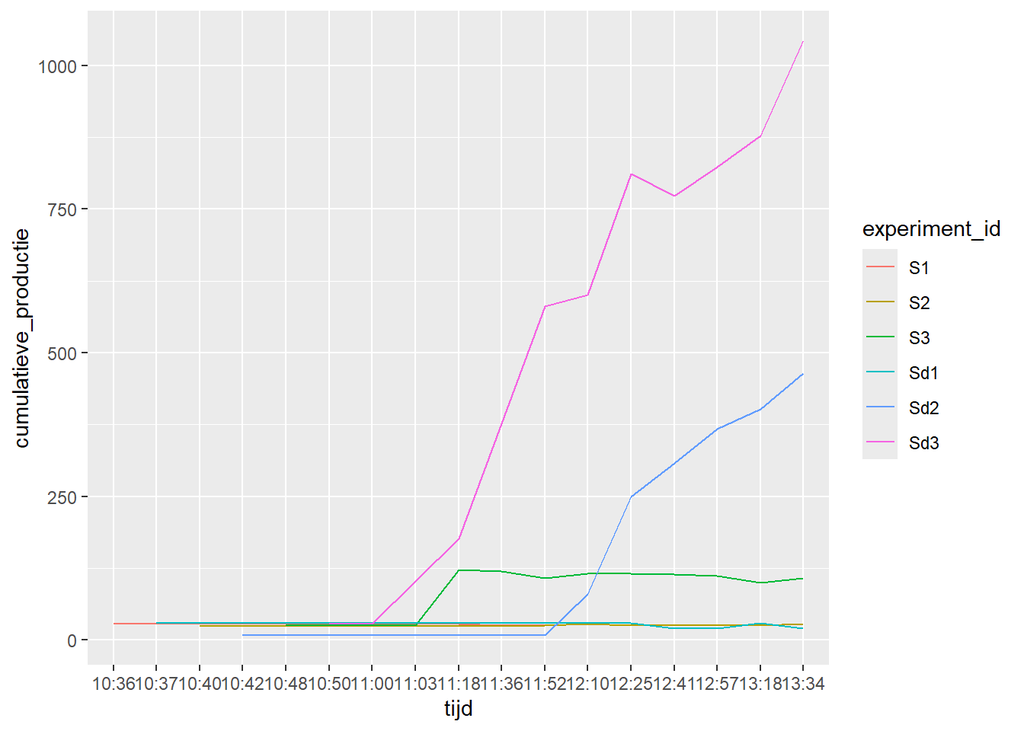

```r
# Lijndiagram

ggplot(data_suiker, aes(x=tijd, y=cumulatieve_productie, group = experiment_id, color=experiment_id)) +
  geom_line()
```

Ik zie dat de Sd3 de grootste groei heeft. In het algemeen nemen de duplo’s de hele diagram in beslag. Nog iets wat niet klopt is de tijd als labels onder. ze hebben allemaal de zelfde interval terwijl de tijd tussen labels niet compleet gelijk is.

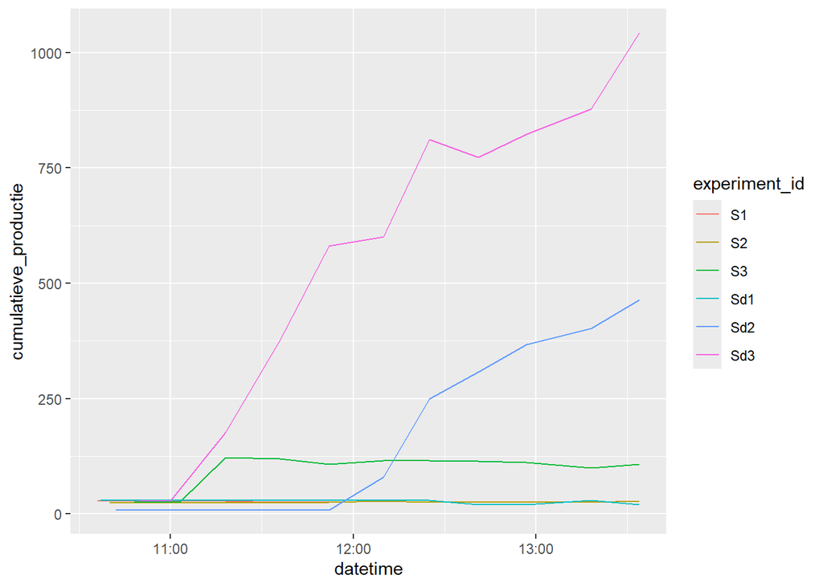

```r
# Tijd correctie
data_suiker$datetime <- with(data_suiker, ymd(data_suiker$datum) + hm(data_suiker$tijd))

# Lijndiagram
ggplot(data_suiker, aes(x=datetime, y=cumulatieve_productie, group = experiment_id, color=experiment_id)) +
  geom_line()
```

De lables zijn nu makkelijker te lezen en de lijn is niet meer geknepen. Hierdoor lijkt de lijn wat meer gelijdelijk te lopen dan de vorige niet gecorigeerde grafiek.

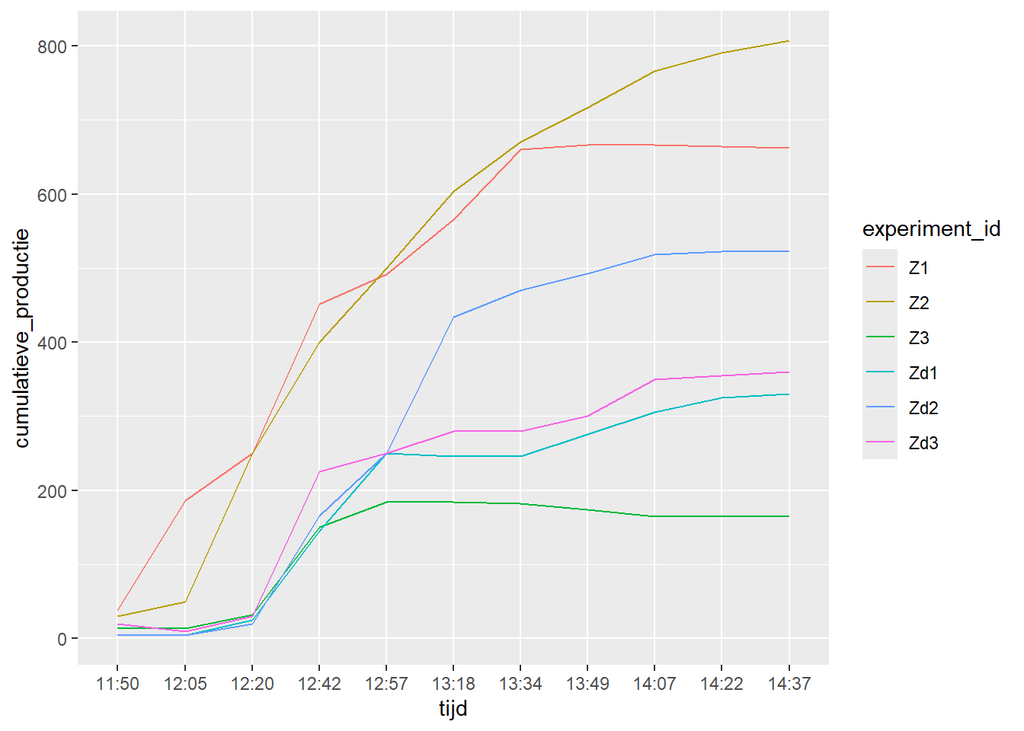

```r
# Lijnplot
ggplot(data_zout, aes(x=tijd, y=cumulatieve_productie, group = experiment_id, color=experiment_id)) +
  geom_line()
```

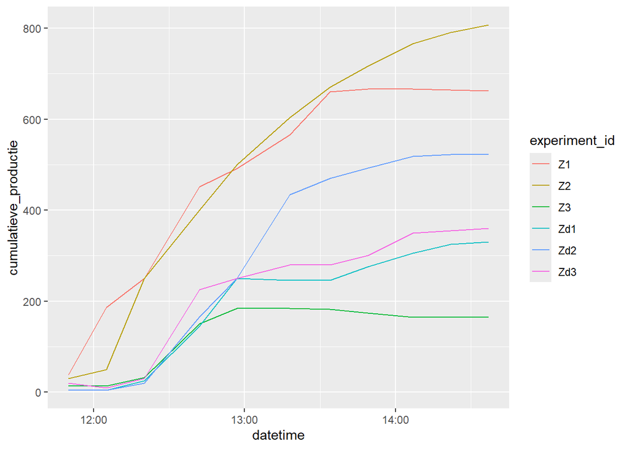

```r
# Tijd correctie
data_zout$datetime <- with(data_zout, ymd(data_zout$datum) + hm(data_zout$tijd))


# Lijn plot
ggplot(data_zout, aes(x=datetime, y=cumulatieve_productie, group = experiment_id, color=experiment_id)) +
  geom_line()
```

De trendlijn van zout lijkt al netter te zijn. Er zijn geen extremen te zien als bij suiker. Het experiment voor zout lijkt voor mij dus betrouwbaarder uitgevoerd te zijn.

## Log [21-5-2024]

<sub>——————————————————————————</sub> ### Taak Ik ga verder werken aan de plot en onze data van het experiment verwerken. Data netter maken en de productie met r berekenen. ### Motivatie Om handmatige fouten te voorkomen wil ik met r nog de productie en de cumulatieve hoeveelheid geproduceerde $CO_2$ berekenen. Bovendien staat de ruwe data niet op een fatsoenlijke manier in de csv. Dit wil ik dus zo maken dat het makkelijk en duidelijk te gebruiken is.

### Resultaat

Nu om te zien of bepaalde waarden van elkaar afwijken en of de data punten aan elkaar gerelateerd zijn, maak ik een aantal spreidingsdiagram Om een correlatie aan te tonen moet ik de verschillende concentraties aan suiker en zout inladen en combineren met de $CO_2$ productie.

```r
# laad gemeten concentraties
path <- paste(here(), "/raw_data/data_gist_werkelijke_concentraties.csv", sep="")
concentratie_data <- read.csv(path)

# Combineer de concentraties met de productie dataframes
sub_data_suiker <- subset(data_suiker, select = -c(datum, tijd, opmerking, meetniveau, null_waarde))
sub_data_zout <- subset(data_zout, select = -c(datum, tijd, opmerking, meetniveau, null_waarde))

# Concateneren van de dataframes
mds <- merge(concentratie_data, sub_data_suiker, by = "experiment_id")
mdz <- merge(concentratie_data, sub_data_zout, by = "experiment_id")
mdsz <- rbind(mds, mdz)
head(mdsz)
```

```
##   experiment_id gist suiker zout  water totaal meting_id temperatuur
## 1            S1 7.03      0 1.14 192.79 200.96         1        32.0
## 2            S1 7.03      0 1.14 192.79 200.96         2        31.4
## 3            S1 7.03      0 1.14 192.79 200.96         3        30.8
## 4            S1 7.03      0 1.14 192.79 200.96         4        30.4
## 5            S1 7.03      0 1.14 192.79 200.96         5        30.0
## 6            S1 7.03      0 1.14 192.79 200.96         6        30.0
##   relatieve_productie cumulatieve_productie            datetime
## 1                   0                    28 2024-05-17 10:36:00
## 2                   0                    28 2024-05-17 11:03:00
## 3                   0                    28 2024-05-17 11:18:00
## 4                  -2                    26 2024-05-17 11:36:00
## 5                   0                    26 2024-05-17 11:52:00
## 6                   2                    28 2024-05-17 12:10:00
```

Nu om de spreidingsdiagram te maken.

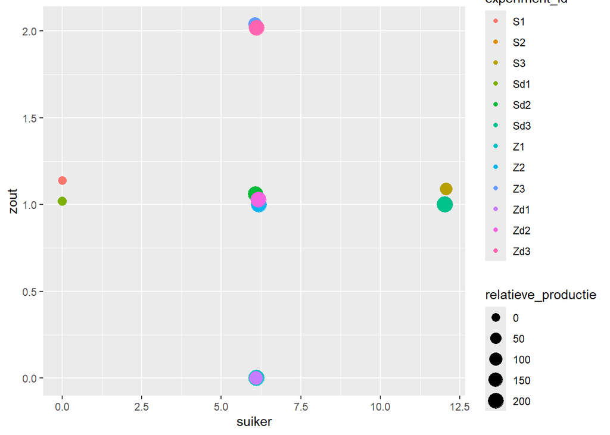

```r
ggplot(mdsz, aes(x=suiker, y=zout,size = relatieve_productie, colour = experiment_id)) +
    geom_point() +
    scale_size()
```

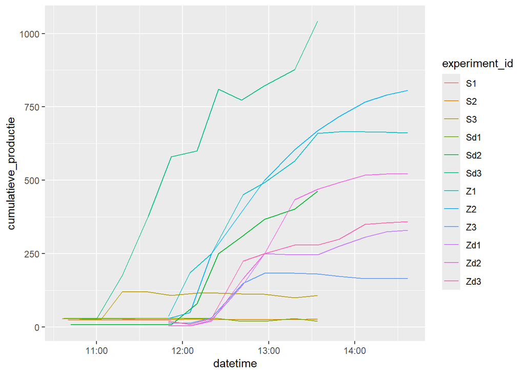

```r
ggplot(mdsz, aes(x=datetime, y=cumulatieve_productie, colour = experiment_id)) +
    geom_line()
```

Er is geen goede manier om een spreidingsdiagram te maken met de data die wij hebben. Ik kan dus geen correlaties vast stellen. Een spreidingsdiagram is dus niet een goede optie. Toch kan ik in de grafiek zien welke permutaties wij hebben gebruik. Uit statistiek hebben wij te horen gekregen over “full factorial design” en “fractal factorial design”. Die gebruik kan worden om correlaties te leggen tussen verschillende variabelen. Voor fractal zou je dan de uiterste punten moeten hebben om een correlatie te kunnen leggen. Jammer genoeg hebben wij dat dus niet.

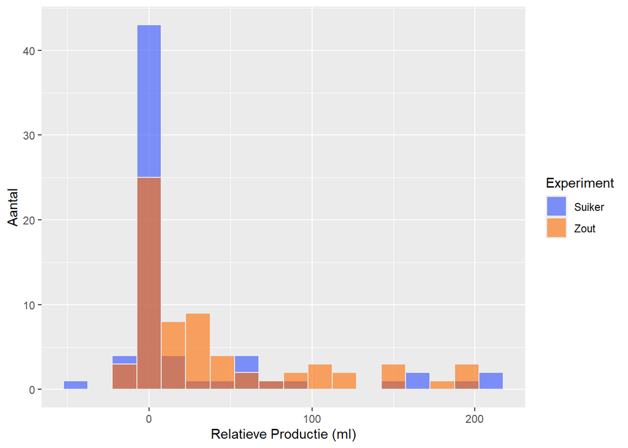

```r
#data_suiker %>% mutate(group = case_match(
#    experiment_id,
#    c("S1", "Sd1") ~ "Es1",
#    c("S2", "Sd2") ~ "Es2",
#    c("S3", "Sd3") ~ "Es3"
#))
mdsz %>% mutate(group = case_match(
    experiment_id,
    c("S1", "Sd1", "S2", "Sd2", "S3", "Sd3") ~ "Suiker",
    c("Z1", "Zd1", "Z2", "Zd2", "Z3", "Zd3") ~ "Zout"
)) %>%
ggplot(aes(x = relatieve_productie, fill = group)) +

    geom_histogram(
        color = "#e9ecef",
        alpha = 0.6,
        binwidth = 15,
        position = 'identity'
    ) +
    scale_fill_manual(name = "Experiment", values = c("#304FFE","#FF6D00")) +
    xlab("Relatieve Productie (ml)") +
    ylab("Aantal")
```

Hier leg ik de twee verdelingen van zout en suiker over elkaar een om te zien of deze normaal verdeeld zijn en of ze vergelijkbaar met elkaar zijn. Voor deze histogram heb ik een binwidth van 15 gebruik. Deze gaf het duidelijkste resultaat. Ik zie geen duidelijke normaal verdeling in deze waarden. Er is wel een verschil te zien tussen de twee verdelingen. De waarden van suiker ligger dichter bij de 0 met een paar uitschieters. Zout daar in tegen lijk veel gelijkmatiger verdeelt te zijn.

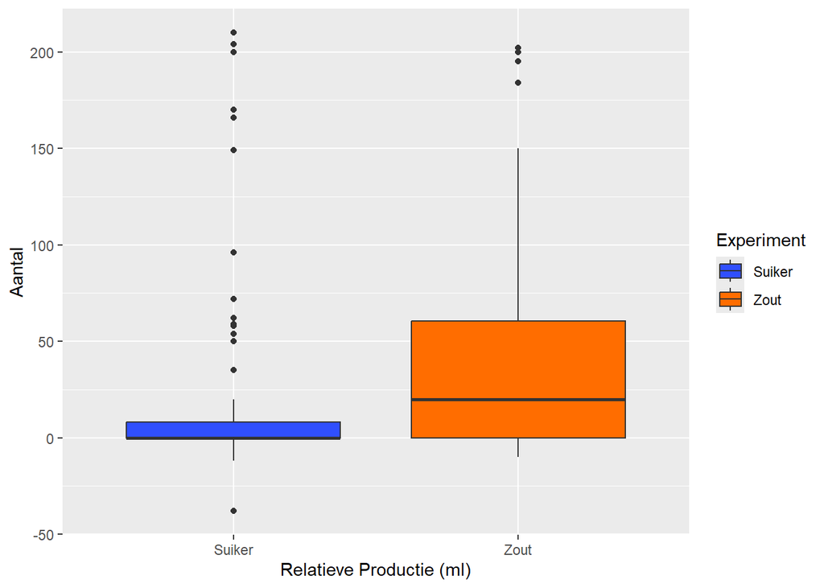

```r
mdsz %>% mutate(group = case_match(
    experiment_id,
    c("S1", "Sd1", "S2", "Sd2", "S3", "Sd3") ~ "Suiker",
    c("Z1", "Zd1", "Z2", "Zd2", "Z3", "Zd3") ~ "Zout"
)) %>%
ggplot(aes(x = group, y = relatieve_productie, fill = group)) +
    geom_boxplot() +
    scale_fill_manual(name = "Experiment", values = c("#304FFE","#FF6D00")) +
    xlab("Relatieve Productie (ml)") +
    ylab("Aantal")
```